# Note S2: Variant hotspot analysis

Marzia A. Cremona

```r
library(readxl)
library(writexl)
library(PoissonBinomial)
```

# Oocytes

## Mutations shared by oocytes from different animals

### Mutation frequency estimation

We estimate the random mutation frequency per nucleotide for our macaque oocyte samples in a conservative way, by counting only mutations found in exactly one oocyte of each macaque and dividing it by the total number of sequenced nucleotides (computed as the sum over all oocytes of the mean sequencing depth for that oocyte times the mtDNA length). Since D-loop generally shows a higher mutation frequency, we estimate this frequency separately for D-loop ($p_{D}$) and for the nucleotides outside of D-loop ($p_{nonD}$). Only oocytes with mean sequencing depth of at least 100x are considered (a total of 119 oocytes among 29 macaques).

Mutation frequency estimation:

```r
n_mut_D = 719
n_mut_nonD = 1116
nt_seq_D = 94814895
nt_seq_nonD = 1352663373

p_D = n_mut_D / nt_seq_D
p_D
```

```
[1] 7.583197e-06
```

```r
p_nonD = n_mut_nonD / nt_seq_nonD
p_nonD
```

```
[1] 8.25039e-07
```

We obtain a random mutation frequency $p_{D}=7.58 \times 10^{-6}$ in the D-loop and $p_{nonD}=8.25 \times 10^{-7}$ outside of the D-loop.

### Probability of calling a mutation in a certain oocyte

We model the process of having a random mutation in a nucleotide of a single molecule as Bernoulli trial $X \sim B(1,p)$, where the probability $p$ is $p_{D}$ for the nucleotides in the D-loop and $p_{nonD}$ for the nucleotides outside the D-loop.

We assume that mutations occur independently in different sequenced molecules, hence the number of mutations per nucleotide in an oocyte is $Y \sim B(d,p)$, where $d$ is the mean sequencing depth of that oocyte. For each oocyte, we can then compute the probability of calling a mutation in a nucleotide as $q = P(Y \geq 1)$.

```r
mut2 <- read_excel("2020-09_Rh_mut_freqs.xlsx", sheet = "Rh_mut_freq")

# select only oocytes with mean depth >= 100x
mut_Oo <- subset(mut2, (mean_depth_DCS >= 100) & (tissue == "oocyte") )
```

Number of oocytes:

```r
nrow(mut_Oo)
```

```
[1] 119
```

Number of macaques:

```r
length(unique(mut_Oo$macaque_ID))
```

```
[1] 29
```

Number of oocytes for each macaque:

```r
n_Oo = table(mut_Oo$macaque_ID)
n_Oo
```

```
Rh015 Rh016 Rh017 Rh020 Rh023 Rh024 Rh025 Rh026 Rh027 Rh029 Rh064 Rh066 Rh067 Rh068 Rh072 Rh074 Rh081 Rh083 Rh084 Rh086 Rh088 Rh094 Rh096
    2     2     5     2     2    10     2     2     2     2    10     2     1     2     2     2    11     2     2     2     2    12     2
Rh097 Rh098 Rh102 Rh104 Rh105 Rh106
    2     7     2    10    11     4
```

Statistics of number of oocytes for each macaque:

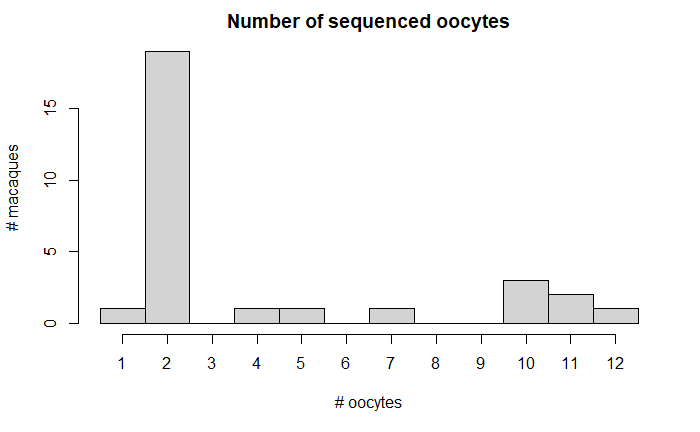

```r
hist(n_Oo, breaks = seq(0.5, max(n_Oo)+0.5), xlim = c(0,max(n_Oo))+0.5, xaxt = "n",
     main = "Number of sequenced oocytes", xlab = "# oocytes", ylab = "# macaques")
axis(side = 1, at = 1:max(n_Oo))
```

Compute the probability of calling a mutation in a nucleotide of D-loop $q_{D}$ and in a nucleotide outside of D-loop $q_{nonD}$:

```r
mut_Oo$q_D = 1 - pbinom(0, size = mut_Oo$mean_depth_DCS, prob = p_D)
mut_Oo$q_nonD = 1 - pbinom(0, size = mut_Oo$mean_depth_DCS, prob = p_nonD)
```

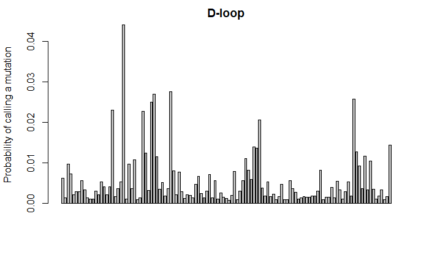

```r
barplot(mut_Oo$q_D, ylab = "Probability of calling a mutation", main = "D-loop")
```

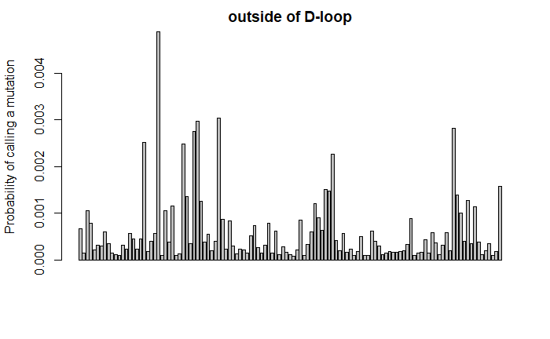

```r
barplot(mut_Oo$q_nonD, ylab = "Probability of calling a mutation", main = "outside of D-loop")
```

### Probability of calling a mutation for each macaque

```r
prob_mut_Oo_macaque = cbind(tapply(mut_Oo$q_D, mut_Oo$macaque_ID,
                                   function(q_i){
                                     1 - ppbinom(0, probs = q_i)
                                   }),
                            tapply(mut_Oo$q_nonD, mut_Oo$macaque_ID,
                                   function(q_i){
                                     1 - ppbinom(0, probs = q_i)
                                   }))
colnames(prob_mut_Oo_macaque) = c('m_D', 'm_nonD')
prob_mut_Oo_macaque
```

```
              m_D       m_nonD
Rh015 0.007449177 0.0008131580
Rh016 0.016805691 0.0018422638
Rh017 0.016276188 0.0017837922
Rh020 0.002264816 0.0002466563
Rh023 0.003859976 0.0004206815
Rh024 0.091780371 0.0104192141
Rh025 0.010627885 0.0011618050
Rh026 0.014147846 0.0015490479
Rh027 0.002052944 0.0002235607
Rh029 0.034706100 0.0038356581
Rh064 0.110719732 0.0126855102
Rh066 0.009712141 0.0010612621
Rh067 0.002801861 0.0003052180
Rh068 0.003247918 0.0003538792
Rh072 0.003210124 0.0003497555
Rh074 0.011317887 0.0012376175
Rh081 0.027210707 0.0029969930
Rh083 0.009659572 0.0010554929
Rh084 0.003882638 0.0004231556
Rh086 0.016485040 0.0018068518
Rh088 0.014005793 0.0015333963
Rh094 0.068469091 0.0076868962
Rh096 0.006402409 0.0006985642
Rh097 0.006296918 0.0006870216
Rh098 0.010267693 0.0011222483
Rh102 0.011100438 0.0012137207
Rh104 0.026635140 0.0029328308
Rh105 0.081662175 0.0092256716
Rh106 0.019917275 0.0021864356
```

### Probability of observing the same mutation in multiple macaques

We now consider all mutations shared by oocytes of multiple macaques. If a mutation is shared by multiple oocytes of the same macaque, we consider it only once.

```r
mut_shared2 <- read_excel("Rh_mutations.xlsx", sheet = "Rh_mutations")

# select only oocytes
mut_shared_Oo <- subset(mut_shared2, (tissue == "oocyte"))

# select only relevant columns and merge mutations shared by multiple oocytes of the same macaque
mut_shared_Oo = unique(mut_shared_Oo[,c("macaque_ID", "mutation", "mut_Rh", "gene_type")])
head(mut_shared_Oo)
```

| macaque_ID | mutation | mut_Rh | gene_type |
| --- | --- | --- | --- |
| Rh015 | 130 T>C | Rh015_130_T>C | D-loop |
| Rh015 | 13642 G>A | Rh015_13642_G>A | protein coding |
| Rh015 | 13811 T>C | Rh015_13811_T>C | protein coding |
| Rh015 | 13871 A>C | Rh015_13871_A>C | protein coding |
| Rh015 | 14882 G>A | Rh015_14882_G>A | protein coding |
| Rh015 | 15129 G>A | Rh015_15129_G>A | protein coding |

Observed distribution of number of macaques with a certain mutation:

```r
n_macaque_mut_Oo = table(mut_shared_Oo$mutation)
n_macaque_mut_Oo = table(factor(n_macaque_mut_Oo, levels = 1:max(n_macaque_mut_Oo)))
n_macaque_mut_Oo
```

```
   1    2    3    4    5    6    7    8    9   10   11   12   13   14
1261  134   45   15    6    7    7    4    0    0    0    0    0    1
```

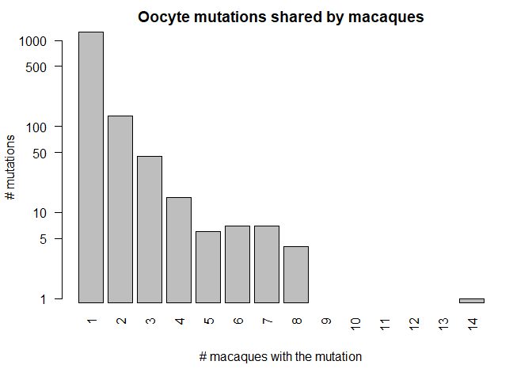

```r
n_macaque_mut_Oo_NA = n_macaque_mut_Oo
n_macaque_mut_Oo_NA[n_macaque_mut_Oo_NA==0] = NA
barplot(n_macaque_mut_Oo_NA, log = "y", xlab = "# macaques with the mutation", ylab = "# mutations", main = "Oocyte mutations shared by macaques", las = 2)
```

Total number of mutations shared by multiple macaques:

```r
sum(n_macaque_mut_Oo[2:length(n_macaque_mut_Oo)])
```

```
[1] 219
```

Select only mutations shared by multiple macaques:

```r
n_Rh = as.data.frame(table(mut_shared_Oo$mutation))
colnames(n_Rh) = c("mutation", "n_Rh")
mut_shared_Oo = merge(mut_shared_Oo, n_Rh, by = "mutation")
mut_shared_Oo = mut_shared_Oo[mut_shared_Oo$n_Rh>1,]
head(mut_shared_Oo)
```

|  | mutation | macaque_ID | mut_Rh | gene_type | n_Rh |
| --- | --- | --- | --- | --- | --- |
| 3 | 10 T>C | Rh094 | Rh094_10_T>C | D-loop | 5 |
| 4 | 10 T>C | Rh105 | Rh105_10_T>C | D-loop | 5 |
| 5 | 10 T>C | Rh017 | Rh017_10_T>C | D-loop | 5 |
| 6 | 10 T>C | Rh064 | Rh064_10_T>C | D-loop | 5 |
| 7 | 10 T>C | Rh081 | Rh081_10_T>C | D-loop | 5 |
| 18 | 101 C>T | Rh064 | Rh064_101_C>T | D-loop | 3 |

Check the total number of mutations shared by multiple macaques:

```r
length(unique(mut_shared_Oo$mutation))
```

```
[1] 219
```

Total number of mutations shared by multiple macaques inside and outside D-loop:

```r
mut_shared_Oo_unique = unique(mut_shared_Oo[,c("mutation", "gene_type")])
c(length(mut_shared_Oo_unique$mutation[mut_shared_Oo_unique$gene_type=="D-loop"]),
  length(mut_shared_Oo_unique$mutation[mut_shared_Oo_unique$gene_type!="D-loop"]))
```

```
[1] 168  51
```

We consider the number of macaques with sequenced oocytes $n_{Rh}=29$. The number of macaques with a mutation in a certain nucleotide is $V = V_1 + \dots + V_{n_{Rh}}$ with $V_i \sim B(1, m_i)$. Assuming independence, we can model $V$ with the Poisson binomial distribution $V \sim PB(n_{Rh}, m_1, \dots, m_{n_{Rh}})$. **We can then compute the probability of observing a mutation in one, two or more macaques by random chance as $P(V=v)$ for $v=1, \dots, n_{Rh}$**.

```r
n_Rh = length(unique(mut_shared_Oo$macaque_ID))

prob_shared_Oo_Rh = cbind(dpbinom(1:n_Rh, probs = prob_mut_Oo_macaque[,"m_D"]),
                      dpbinom(1:n_Rh, probs = prob_mut_Oo_macaque[,"m_nonD"]))
colnames(prob_shared_Oo_Rh) = c('P(V=v)_D', 'P(V=v)_nonD')
row.names(prob_shared_Oo_Rh) = 1:n_Rh
prob_shared_Oo_Rh
```

```
       P(V=v)_D  P(V=v)_nonD
1  3.523637e-01 6.730673e-02
2  1.089922e-01 2.208845e-03
3  2.034028e-02 4.384504e-05
4  2.578664e-03 5.926201e-07
5  2.372268e-04 5.824902e-09
6  1.652410e-05 4.343062e-11
7  8.977663e-07 2.529831e-13
8  3.888396e-08 1.176366e-15
9  1.364835e-09 4.438155e-18
10 3.931390e-11 1.375472e-20
11 9.382899e-13 3.535084e-23
12 1.868957e-14 7.588282e-26
13 3.123436e-16 1.367551e-28
14 4.395502e-18 2.076534e-31
15 5.219695e-20 2.662089e-34
16 5.234196e-22 2.883235e-37
17 4.429266e-24 2.636351e-40
18 3.156340e-26 2.030819e-43
19 1.887269e-28 1.313106e-46
20 9.417857e-31 7.088427e-50
21 3.893132e-33 3.170833e-53
22 1.319727e-35 1.163516e-56
23 3.618884e-38 3.454678e-60
24 7.878570e-41 8.146104e-64
25 1.326299e-43 1.485705e-67
26 1.660197e-46 2.015357e-71
27 1.451020e-49 1.909301e-75
28 7.883313e-53 1.124657e-79
29 1.999818e-56 3.093905e-84
```

### Expected number of shared mutations

Finally, we can compute the expected number of random mutations present at the same site in one, two or more macaques by multiplying the probability $P(V=v)$ by the mtDNA length (i.e., 1085 nucleotides for D-loop and 15479 nucleotides outside of D-loop).

```r
nt_D = 1085
nt_nonD = 15479

expected_shared_Oo_Rh = t(t(prob_shared_Oo_Rh) * c(nt_D, nt_nonD))
expected_shared_Oo_Rh = cbind(expected_shared_Oo_Rh, rowSums(expected_shared_Oo_Rh))
colnames(expected_shared_Oo_Rh) = c('exp_mut_D', 'exp_mut_nonD', 'exp_mut_tot')
expected_shared_Oo_Rh
```

```
      exp_mut_D exp_mut_nonD  exp_mut_tot
1  3.823146e+02 1.041841e+03 1.424156e+03
2  1.182566e+02 3.419071e+01 1.524473e+02
3  2.206921e+01 6.786773e-01 2.274788e+01
4  2.797850e+00 9.173167e-03 2.807023e+00
5  2.573910e-01 9.016366e-05 2.574812e-01
6  1.792865e-02 6.722626e-07 1.792932e-02
7  9.740764e-04 3.915925e-09 9.740803e-04
8  4.218910e-05 1.820898e-11 4.218912e-05
9  1.480846e-06 6.869820e-14 1.480846e-06
10 4.265558e-08 2.129094e-16 4.265558e-08
11 1.018045e-09 5.471956e-19 1.018045e-09
12 2.027818e-11 1.174590e-21 2.027818e-11
13 3.388928e-13 2.116832e-24 3.388928e-13
14 4.769119e-15 3.214267e-27 4.769119e-15
15 5.663369e-17 4.120647e-30 5.663369e-17
16 5.679102e-19 4.462960e-33 5.679102e-19
17 4.805753e-21 4.080808e-36 4.805753e-21
18 3.424629e-23 3.143504e-39 3.424629e-23
19 2.047687e-25 2.032557e-42 2.047687e-25
20 1.021838e-27 1.097218e-45 1.021838e-27
21 4.224048e-30 4.908132e-49 4.224048e-30
22 1.431904e-32 1.801006e-52 1.431904e-32
23 3.926489e-35 5.347497e-56 3.926489e-35
24 8.548249e-38 1.260935e-59 8.548249e-38
25 1.439035e-40 2.299723e-63 1.439035e-40
26 1.801314e-43 3.119572e-67 1.801314e-43
27 1.574356e-46 2.955407e-71 1.574356e-46
28 8.553395e-50 1.740856e-75 8.553395e-50
29 2.169803e-53 4.789056e-80 2.169803e-53
```

Observed number of shared mutations:

```r
shared_Oo_Rh = cbind(expected_shared_Oo_Rh, c(n_macaque_mut_Oo_NA, rep(NA, n_Rh-length(n_macaque_mut_Oo_NA))), 0)
colnames(shared_Oo_Rh)[4:5] = c("obs_mut_tot", "delta")
shared_Oo_Rh[,"delta"] = shared_Oo_Rh[,"obs_mut_tot"] - shared_Oo_Rh[,"exp_mut_tot"]
shared_Oo_Rh
```

```
      exp_mut_D exp_mut_nonD  exp_mut_tot obs_mut_tot       delta
1  3.823146e+02 1.041841e+03 1.424156e+03        1261 -163.155547
2  1.182566e+02 3.419071e+01 1.524473e+02         134  -18.447279
3  2.206921e+01 6.786773e-01 2.274788e+01          45   22.252117
4  2.797850e+00 9.173167e-03 2.807023e+00          15   12.192977
5  2.573910e-01 9.016366e-05 2.574812e-01           6    5.742519
6  1.792865e-02 6.722626e-07 1.792932e-02           7    6.982071
7  9.740764e-04 3.915925e-09 9.740803e-04           7    6.999026
8  4.218910e-05 1.820898e-11 4.218912e-05           4    3.999958
9  1.480846e-06 6.869820e-14 1.480846e-06          NA          NA
10 4.265558e-08 2.129094e-16 4.265558e-08          NA          NA
11 1.018045e-09 5.471956e-19 1.018045e-09          NA          NA
12 2.027818e-11 1.174590e-21 2.027818e-11          NA          NA
13 3.388928e-13 2.116832e-24 3.388928e-13          NA          NA
14 4.769119e-15 3.214267e-27 4.769119e-15           1    1.000000
15 5.663369e-17 4.120647e-30 5.663369e-17          NA          NA
16 5.679102e-19 4.462960e-33 5.679102e-19          NA          NA
17 4.805753e-21 4.080808e-36 4.805753e-21          NA          NA
18 3.424629e-23 3.143504e-39 3.424629e-23          NA          NA
19 2.047687e-25 2.032557e-42 2.047687e-25          NA          NA
20 1.021838e-27 1.097218e-45 1.021838e-27          NA          NA
21 4.224048e-30 4.908132e-49 4.224048e-30          NA          NA
22 1.431904e-32 1.801006e-52 1.431904e-32          NA          NA
23 3.926489e-35 5.347497e-56 3.926489e-35          NA          NA
24 8.548249e-38 1.260935e-59 8.548249e-38          NA          NA
25 1.439035e-40 2.299723e-63 1.439035e-40          NA          NA
26 1.801314e-43 3.119572e-67 1.801314e-43          NA          NA
27 1.574356e-46 2.955407e-71 1.574356e-46          NA          NA
28 8.553395e-50 1.740856e-75 8.553395e-50          NA          NA
29 2.169803e-53 4.789056e-80 2.169803e-53          NA          NA
```

Total number of expected shared mutations:

```r
colSums(shared_Oo_Rh[-1,], na.rm = TRUE)
```

```
   exp_mut_D exp_mut_nonD  exp_mut_tot  obs_mut_tot        delta
   143.39996     34.87865    178.27861    219.00000     40.72139
```

**We expect to observe around 178 mutation sites shared by different macaques (143 in D-loop and 35 outside D-loop). We actually observe 219 shared sites (168 in D-loop and 51 outside D-loop).**

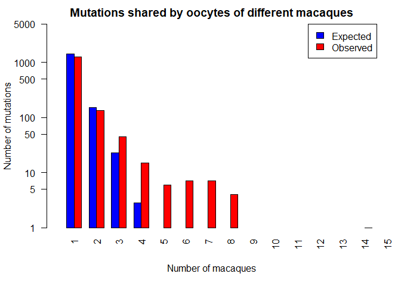

```r
shared_Oo_Rh_NA = shared_Oo_Rh[,c("exp_mut_tot","obs_mut_tot")]
shared_Oo_Rh_NA[shared_Oo_Rh_NA<0.5] = NA
barplot(t(shared_Oo_Rh_NA), xlab = "Number of macaques", ylab = "Number of mutations", main = "Mutations shared by oocytes of different macaques", log = "y", xlim = c(0,41), ylim = c(1,5000), beside = TRUE, col = c("blue", "red"), las = 2)
legend("topright", legend = c("Expected", "Observed"), fill = c("blue", "red"))
```

### Hotspot mutations identification

In order to better identify the hotspot mutations, i.e. the mutations that are shared by multiple macaques but are not expected to be shared, we consider each of 219 shared mutations and we compute the probability of observing it exactly in those macaques in which we are observing it. This way, we can rank the shared mutations based on how unusual they are, taking into consideration in which macaques we found them (hence, also the number of oocytes sequenced for those macaques and their sequencing depth).

For each of the 219 shared mutation, we consider the $n_{Rh,i}$ macaques in which we observed it. If the mutation is present in the macaques $j, \dots, j_{n_{Rh,i}}$ and is not present in the macaques $k, \dots, k_{n_{Rh}-n_{Rh,i}}$, assuming independence among random mutations in different macaques we obtain that the probability of observing such a mutation in exactly those macaques is $m_j \times \cdots \times m_{j_{n_{Rh,i}}} \times (1-m_k) \times \cdots \times (1-m_{k_{n_{Rh}-n_{Rh,i}}})$.

```r
mut_shared_Oo_prob = unique(mut_shared_Oo[,c("mutation", "gene_type", "n_Rh")])
mut_shared_Oo_prob$prob = unlist(lapply(unique(mut_shared_Oo$mutation),
                                     function(mutation){
                                       mut_shared_i = mut_shared_Oo[mut_shared_Oo$mutation==mutation,]
                                       if(mut_shared_i$gene_type[1]=="D-loop"){
                                         m = prob_mut_Oo_macaque[,"m_D"]
                                       }else{
                                         m = prob_mut_Oo_macaque[,"m_nonD"]
                                       }
                                       j = names(m) %in% mut_shared_i$macaque_ID
                                       return(prod(c(m[j], (1-m[!j]))))
                                     }))
mut_shared_Oo_prob = mut_shared_Oo_prob[order(mut_shared_Oo_prob$prob),]
head(mut_shared_Oo_prob)
```

|  | mutation | gene_type | n_Rh | prob |
| --- | --- | --- | --- | --- |
| 775 | 16304 G>A | D-loop | 14 | 2.568635e-24 |
| 850 | 16367 C>T | D-loop | 8 | 5.609912e-17 |
| 889 | 16384 G>A | D-loop | 8 | 6.929267e-16 |
| 1413 | 4554 T>A | protein coding | 6 | 1.245760e-15 |
| 1105 | 198 C>T | D-loop | 7 | 1.062181e-14 |
| 734 | 16277 T>C | D-loop | 8 | 4.355122e-14 |

Save results:

```r
write_xlsx(mut_shared_Oo_prob, "shared_mutation_multiple_Rh_oocytes.xlsx")
```

# Liver

## Mutations shared by liver from different animals

### Mutation frequency estimation

The random mutation frequency per nucleotide estimation is done similarly to the oocyte case, by counting all mutations found in liver tissue (in all 30 macaques, since the mean sequencing depth is pretty high for all of them) and dividing it by the total number of sequenced nucleotides. The random mutation frequency is estimated separately for D-loop.

Mutation frequency estimation:

```r
n_mut_D = 980
n_mut_nonD = 8409
nt_seq_D = 94745455
nt_seq_nonD = 1351672717

p_D = n_mut_D / nt_seq_D
p_D
```

```
[1] 1.03435e-05
```

```r
p_nonD = n_mut_nonD / nt_seq_nonD
p_nonD
```

```
[1] 6.221181e-06
```

We obtain a random mutation frequency $p_{D}=1.03 \times 10^{-5}$ in the D-loop and $p_{nonD}=6.22 \times 10^{-6}$ outside of the D-loop.

### Probability of calling a mutation for each macaque

As above, we model the process of having a random mutation in a nucleotide of a single molecule as Bernoulli trial $X \sim B(1,p)$, where the probability $p$ is $p_{D}$ for the nucleotides in the D-loop and $p_{nonD}$ for the nucleotides outside the D-loop.

We assume that mutations occur independently in different sequenced molecules, hence the number of mutations per nucleotide in a liver sample is $Y \sim B(d,p)$, where $d$ is the mean sequencing depth of that liver sample. For each liver sample, we can then compute the probability of calling a mutation in a nucleotide as $q = P(Y \geq 1)$.

```r
# select only liver samples with mean depth >= 100x
mut_liver <- subset(mut2, (mean_depth_DCS >= 100) & (tissue == "liver") )
```

Number of macaques:

```r
length(unique(mut_liver$macaque_ID))
```

```
[1] 30
```

Compute the probability of calling a mutation in a nucleotide of D-loop $q_{D}$ and in a nucleotide outside of D-loop $q_{nonD}$:

```r
mut_liver$q_D = 1 - pbinom(0, size = mut_liver$mean_depth_DCS, prob = p_D)
mut_liver$q_nonD = 1 - pbinom(0, size = mut_liver$mean_depth_DCS, prob = p_nonD)
```

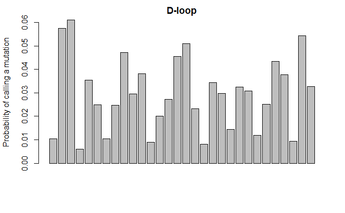

```r
barplot(mut_liver$q_D, ylab = "Probability of calling a mutation", main = "D-loop")
```

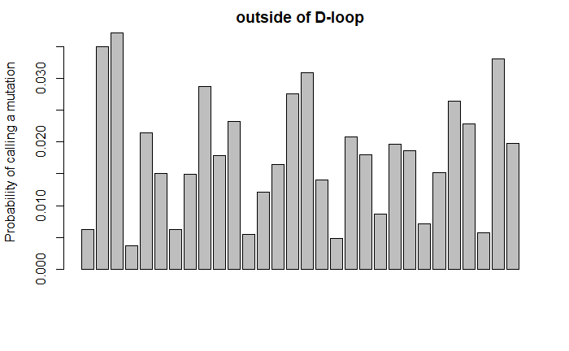

```r
barplot(mut_liver$q_nonD, ylab = "Probability of calling a mutation", main = "outside of D-loop")
```

### Probability of observing the same mutation in multiple macaques

We now consider all mutations shared by liver samples of multiple macaques.

```r
# select only liver
mut_shared_liver <- subset(mut_shared2, (tissue == "liver"))

# select only relevant columns
mut_shared_liver = mut_shared_liver[,c("macaque_ID", "mutation", "mut_Rh", "gene_type")]
head(mut_shared_liver)
```

| macaque_ID | mutation | mut_Rh | gene_type |
| --- | --- | --- | --- |
| Rh015 | 10161 G>A | Rh015_10161_G>A | protein coding |
| Rh015 | 10240 T>C | Rh015_10240_T>C | protein coding |
| Rh015 | 10379 G>A | Rh015_10379_G>A | protein coding |
| Rh015 | 10624 T>C | Rh015_10624_T>C | protein coding |
| Rh015 | 10640 C>G | Rh015_10640_C>G | protein coding |
| Rh015 | 10670 A>G | Rh015_10670_A>G | protein coding |

Observed distribution of number of macaques with a certain mutation:

```r
n_macaque_mut_liver = table(mut_shared_liver$mutation)
n_macaque_mut_liver = table(factor(n_macaque_mut_liver, levels = 1:max(n_macaque_mut_liver)))
n_macaque_mut_liver
```

```
   1    2    3    4    5    6    7    8    9   10   11   12   13   14   15   16   17   18
3048  853  428  217  123   87   50   25   14   16   13    8    3    5    4    2    2    2
```

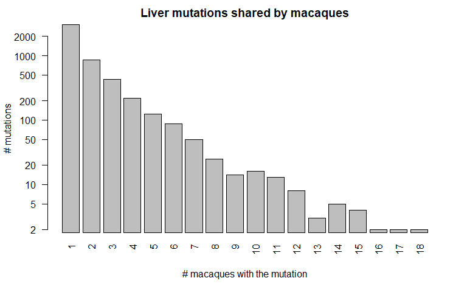

```r
n_macaque_mut_liver_NA = n_macaque_mut_liver
n_macaque_mut_liver_NA[n_macaque_mut_liver_NA==0] = NA
barplot(n_macaque_mut_liver_NA, log = "y", xlab = "# macaques with the mutation", ylab = "# mutations", main = "Liver mutations shared by macaques", las = 2)
```

Total number of mutations shared by multiple macaques:

```r
sum(n_macaque_mut_liver[2:length(n_macaque_mut_liver)])
```

```
[1] 1852
```

Select only mutations shared by multiple macaques:

```r
n_Rh = as.data.frame(table(mut_shared_liver$mutation))
colnames(n_Rh) = c("mutation", "n_Rh")
mut_shared_liver = merge(mut_shared_liver, n_Rh, by = "mutation")
mut_shared_liver = mut_shared_liver[mut_shared_liver$n_Rh>1,]
head(mut_shared_liver)
```

|  | mutation | macaque_ID | mut_Rh | gene_type | n_Rh |
| --- | --- | --- | --- | --- | --- |
| 2 | 10008 G>A | Rh027 | Rh027_10008_G>A | tRNA | 2 |
| 3 | 10008 G>A | Rh066 | Rh066_10008_G>A | tRNA | 2 |
| 6 | 10017 T>C | Rh102 | Rh102_10017_T>C | tRNA | 3 |
| 7 | 10017 T>C | Rh027 | Rh027_10017_T>C | tRNA | 3 |
| 8 | 10017 T>C | Rh016 | Rh016_10017_T>C | tRNA | 3 |
| 10 | 10021 T>C | Rh105 | Rh105_10021_T>C | tRNA | 2 |

Check the total number of mutations shared by multiple macaques:

```r
length(unique(mut_shared_liver$mutation))
```

```
[1] 1852
```

Total number of mutations shared by multiple macaques inside and outside D-loop:

```r
mut_shared_liver_unique = unique(mut_shared_liver[,c("mutation", "gene_type")])
c(length(mut_shared_liver_unique$mutation[mut_shared_liver_unique$gene_type=="D-loop"]),
  length(mut_shared_liver_unique$mutation[mut_shared_liver_unique$gene_type!="D-loop"]))
```

```
[1]  177 1675
```

We consider the number of macaques with sequenced liver $n_{Rh}=30$. The number of macaques with a mutation in a certain nucleotide is $V = V_1 + \dots + V_{n_{Rh}}$ with $V_i \sim B(1, q_i)$. Assuming independence, we can model $V$ with the Poisson binomial distribution $V \sim PB(n_{Rh}, q_1, \dots, q_{n_{Rh}})$. **We can then compute the probability of observing a mutation in one, two or more macaques by random chance as $P(V=v)$ for $v=1, \dots, n_{Rh}$**.

```r
n_Rh = length(unique(mut_shared_liver$macaque_ID))

prob_shared_liver_Rh = cbind(dpbinom(1:n_Rh, probs = mut_liver$q_D),
                             dpbinom(1:n_Rh, probs = mut_liver$q_nonD))
colnames(prob_shared_liver_Rh) = c('P(V=v)_D', 'P(V=v)_nonD')
row.names(prob_shared_liver_Rh) = 1:n_Rh
prob_shared_liver_Rh
```

```
       P(V=v)_D  P(V=v)_nonD
1  3.732035e-01 3.192432e-01
2  1.644642e-01 8.397165e-02
3  4.617977e-02 1.407486e-02
4  9.281137e-03 1.688770e-03
5  1.421878e-03 1.544736e-04
6  1.726735e-04 1.120177e-05
7  1.706584e-05 6.611566e-07
8  1.398494e-06 3.235936e-08
9  9.632208e-08 1.331300e-09
10 5.632454e-09 4.650574e-11
11 2.817243e-10 1.389764e-12
12 1.211949e-11 3.572393e-14
13 4.501456e-13 7.929339e-16
14 1.447142e-14 1.523548e-17
```

[output cut: 16 more lines]

### Expected number of shared mutations

Finally, we can compute the expected number of random mutations present at the same site in one, two or more macaques by multiplying the probability $P(V=v)$ by the mtDNA length (i.e., 1085 nucleotides for D-loop and 15479 nucleotides outside of D-loop).

```r
nt_D = 1085
nt_nonD = 15479

expected_shared_liver_Rh = t(t(prob_shared_liver_Rh) * c(nt_D, nt_nonD))
expected_shared_liver_Rh = cbind(expected_shared_liver_Rh, rowSums(expected_shared_liver_Rh))
colnames(expected_shared_liver_Rh) = c('exp_mut_D', 'exp_mut_nonD', 'exp_mut_tot')
expected_shared_liver_Rh
```

```
      exp_mut_D exp_mut_nonD  exp_mut_tot
1  4.049258e+02 4.941565e+03 5.346491e+03
2  1.784436e+02 1.299797e+03 1.478241e+03
3  5.010505e+01 2.178648e+02 2.679699e+02
4  1.007003e+01 2.614046e+01 3.621050e+01
5  1.542738e+00 2.391097e+00 3.933835e+00
6  1.873507e-01 1.733921e-01 3.607428e-01
7  1.851644e-02 1.023404e-02 2.875048e-02
8  1.517366e-03 5.008905e-04 2.018256e-03
9  1.045095e-04 2.060719e-05 1.251166e-04
10 6.111213e-06 7.198624e-07 6.831075e-06
11 3.056708e-07 2.151216e-08 3.271830e-07
12 1.314964e-08 5.529707e-10 1.370261e-08
13 4.884080e-10 1.227382e-11 5.006818e-10
14 1.570149e-11 2.358300e-13 1.593732e-11
```

[output cut: 16 more lines]

Observed number of shared mutations:

```r
shared_liver_Rh = cbind(expected_shared_liver_Rh, c(n_macaque_mut_liver_NA, rep(NA, n_Rh-length(n_macaque_mut_liver_NA))), 0)
colnames(shared_liver_Rh)[4:5] = c("obs_mut_tot", "delta")
shared_liver_Rh[,"delta"] = shared_liver_Rh[,"obs_mut_tot"] - shared_liver_Rh[,"exp_mut_tot"]
shared_liver_Rh
```

```
      exp_mut_D exp_mut_nonD  exp_mut_tot obs_mut_tot       delta
1  4.049258e+02 4.941565e+03 5.346491e+03        3048 -2298.49091
2  1.784436e+02 1.299797e+03 1.478241e+03         853  -625.24081
3  5.010505e+01 2.178648e+02 2.679699e+02         428   160.03013
4  1.007003e+01 2.614046e+01 3.621050e+01         217   180.78950
5  1.542738e+00 2.391097e+00 3.933835e+00         123   119.06616
6  1.873507e-01 1.733921e-01 3.607428e-01          87    86.63926
7  1.851644e-02 1.023404e-02 2.875048e-02          50    49.97125
8  1.517366e-03 5.008905e-04 2.018256e-03          25    24.99798
9  1.045095e-04 2.060719e-05 1.251166e-04          14    13.99987
10 6.111213e-06 7.198624e-07 6.831075e-06          16    15.99999
11 3.056708e-07 2.151216e-08 3.271830e-07          13    13.00000
12 1.314964e-08 5.529707e-10 1.370261e-08           8     8.00000
13 4.884080e-10 1.227382e-11 5.006818e-10           3     3.00000
14 1.570149e-11 2.358300e-13 1.593732e-11           5     5.00000
```

[output cut: 16 more lines]

Total number of expected shared mutations:

```r
colSums(shared_liver_Rh[-1,], na.rm = TRUE)
```

```
   exp_mut_D exp_mut_nonD  exp_mut_tot  obs_mut_tot        delta
   240.36892   1546.37774   1786.74666   1852.00000     65.25334
```

**We expect to observe around 1787 mutation sites shared by different macaques (240 in D-loop and 1546 outside D-loop). We actually observe 1852 shared sites (177 in D-loop and 1675 outside D-loop).**

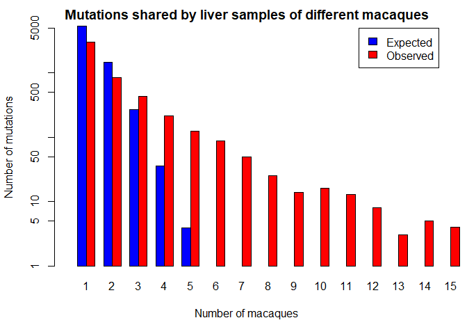

```r
shared_liver_Rh_NA = shared_liver_Rh[,c("exp_mut_tot","obs_mut_tot")]
shared_liver_Rh_NA[shared_liver_Rh_NA<0.5] = NA
barplot(t(shared_liver_Rh_NA), xlab = "Number of macaques", ylab = "Number of mutations", main = "Mutations shared by liver samples of different macaques", log = "y", xlim = c(0,41), ylim = c(1,5000), beside = TRUE, col = c("blue", "red"))
legend("topright", legend = c("Expected", "Observed"), fill = c("blue", "red"))
```

### Hotspot mutations identification

In order to better identify the hotspot mutations, i.e. the mutations that are shared by multiple macaques but are not expected to be shared, we consider each of 1852 shared mutations and we compute the probability of observing it exactly in those macaques in which we are observing it. This way, we can rank the shared mutations based on how unusual they are, taking into consideration in which macaques we found them (hence, also the sequencing depth for each sample).

For each of the 1852 shared mutation, we consider the $n_{Rh,i}$ macaques in which we observed it. If the mutation is present in the macaques $j, \dots, j_{n_{Rh,i}}$ and is not present in the macaques $k, \dots, k_{n_{Rh}-n_{Rh,i}}$, assuming independence among random mutations in different macaques we obtain that the probability of observing such a mutation in exactly those macaques is $q_j \times \cdots \times q_{j_{n_{Rh,i}}} \times (1-q_k) \times \cdots \times (1-q_{k_{n_{Rh}-n_{Rh,i}}})$.

```r
mut_shared_liver_prob = unique(mut_shared_liver[,c("mutation", "gene_type", "n_Rh")])
mut_shared_liver_prob$prob = unlist(lapply(unique(mut_shared_liver$mutation),
                                           function(mutation){
                                             mut_shared_i = mut_shared_liver[mut_shared_liver$mutation==mutation,]
                                             if(mut_shared_i$gene_type[1]=="D-loop"){
                                               q = mut_liver$q_D
                                             }else{
                                               q = mut_liver$q_nonD
                                             }
                                             j = mut_liver$macaque_ID %in% mut_shared_i$macaque_ID
                                             return(prod(c(q[j], (1-q[!j]))))
                                           }))
mut_shared_liver_prob = mut_shared_liver_prob[order(mut_shared_liver_prob$prob),]
head(mut_shared_liver_prob)
```

|  | mutation | gene_type | n_Rh | prob |
| --- | --- | --- | --- | --- |
| 6782 | 5698 G>A | noncoding | 18 | 8.164257e-33 |
| 771 | 11553 G>A | protein coding | 18 | 2.156899e-32 |
| 804 | 11583 G>A | protein coding | 17 | 1.387073e-29 |
| 1448 | 127 G>A | D-loop | 17 | 1.004433e-27 |
| 3489 | 15990 G>A | tRNA | 15 | 2.011104e-27 |
| 3038 | 15380 G>A | protein coding | 15 | 1.330837e-26 |

Save results:

```r
write_xlsx(mut_shared_liver_prob, "shared_mutation_multiple_Rh_liver.xlsx")
```

# Muscle

## Mutations shared by muscle from different animals

### Mutation frequency estimation

The random mutation frequency per nucleotide estimation is done similarly to the oocyte and liver cases, by counting all mutations found in muscle tissue (in all 30 macaques, since the mean sequencing depth is pretty high for all of them) and dividing it by the total number of sequenced nucleotides. The random mutation frequency is estimated separately for D-loop.

Mutation frequency estimation:

```r
n_mut_D = 853
n_mut_nonD = 4145
nt_seq_D = 111848310
nt_seq_nonD = 1595668194

p_D = n_mut_D / nt_seq_D
p_D
```

```
[1] 7.6264e-06
```

```r
p_nonD = n_mut_nonD / nt_seq_nonD
p_nonD
```

```
[1] 2.597658e-06
```

We obtain a random mutation frequency $p_{D}=7.63 \times 10^{-6}$ in the D-loop and $p_{nonD}=2.60 \times 10^{-6}$ outside of the D-loop.

### Probability of calling a mutation for each macaque

As above, we model the process of having a random mutation in a nucleotide of a single molecule as Bernoulli trial $X \sim B(1,p)$, where the probability $p$ is $p_{D}$ for the nucleotides in the D-loop and $p_{nonD}$ for the nucleotides outside the D-loop.

We assume that mutations occur independently in different sequenced molecules, hence the number of mutations per nucleotide in a muscle sample is $Y \sim B(d,p)$, where $d$ is the mean sequencing depth of that liver sample. For each muscle sample, we can then compute the probability of calling a mutation in a nucleotide as $q = P(Y \geq 1)$.

```r
# select only muscle samples with mean depth >= 100x
mut_muscle <- subset(mut2, (mean_depth_DCS >= 100) & (tissue == "muscle") )
```

Number of macaques:

```r
length(unique(mut_muscle$macaque_ID))
```

```
[1] 30
```

Compute the probability of calling a mutation in a nucleotide of D-loop $q_{D}$ and in a nucleotide outside of D-loop $q_{nonD}$:

```r
mut_muscle$q_D = 1 - pbinom(0, size = mut_muscle$mean_depth_DCS, prob = p_D)
mut_muscle$q_nonD = 1 - pbinom(0, size = mut_muscle$mean_depth_DCS, prob = p_nonD)
```

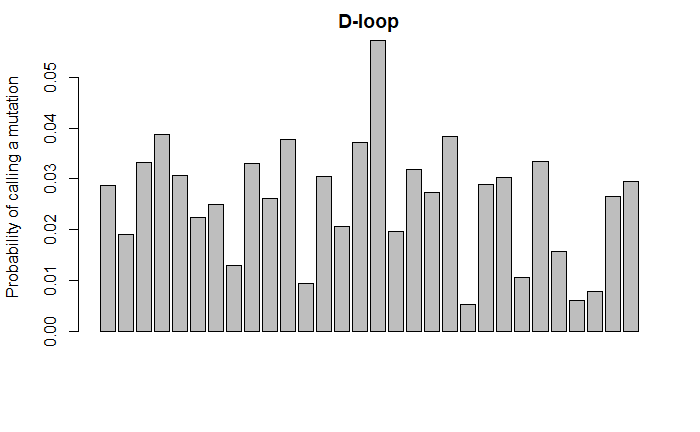

```r
barplot(mut_muscle$q_D, ylab = "Probability of calling a mutation", main = "D-loop")
```

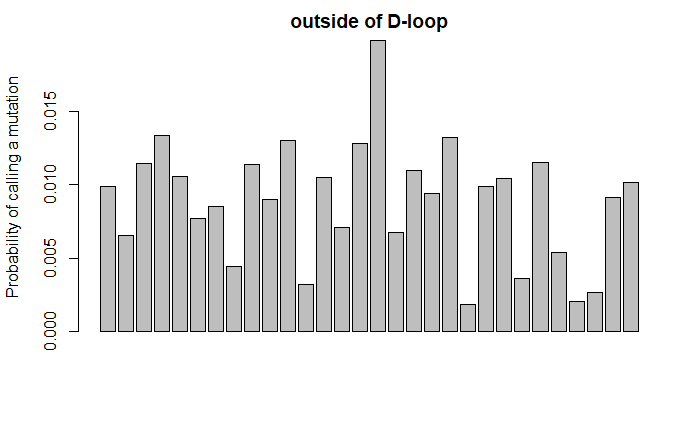

```r
barplot(mut_muscle$q_nonD, ylab = "Probability of calling a mutation", main = "outside of D-loop")
```

### Probability of observing the same mutation in multiple macaques

We now consider all mutations shared by muscle samples of multiple macaques.

```r
# select only liver
mut_shared_muscle <- subset(mut_shared2, (tissue == "muscle"))

# select only relevant columns
mut_shared_muscle = mut_shared_muscle[,c("macaque_ID", "mutation", "mut_Rh", "gene_type")]
head(mut_shared_muscle)
```

| macaque_ID | mutation | mut_Rh | gene_type |
| --- | --- | --- | --- |
| Rh015 | 10045 G>A | Rh015_10045_G>A | tRNA |
| Rh015 | 10072 C>A | Rh015_10072_C>A | protein coding |
| Rh015 | 10107 A>G | Rh015_10107_A>G | protein coding |
| Rh015 | 10153 G>A | Rh015_10153_G>A | protein coding |
| Rh015 | 10281 G>A | Rh015_10281_G>A | protein coding |
| Rh015 | 10401 A>G | Rh015_10401_A>G | tRNA |

Observed distribution of number of macaques with a certain mutation:

```r
n_macaque_mut_muscle = table(mut_shared_muscle$mutation)
n_macaque_mut_muscle = table(factor(n_macaque_mut_muscle, levels = 1:max(n_macaque_mut_muscle)))
n_macaque_mut_muscle
```

```
   1    2    3    4    5    6    7    8    9   10   11   12   13   14
2474  523  207   59   40   17   12    7    6    4    3    1    2    1
```

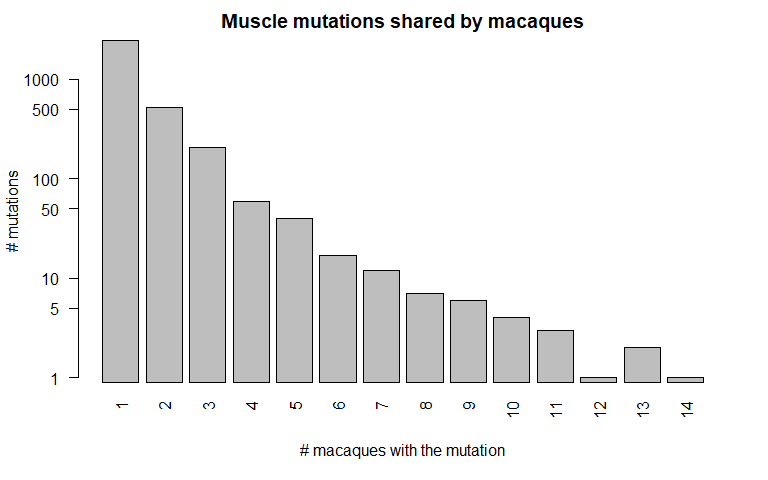

```r
n_macaque_mut_muscle_NA = n_macaque_mut_muscle
n_macaque_mut_muscle_NA[n_macaque_mut_muscle_NA==0] = NA
barplot(n_macaque_mut_muscle_NA, log = "y", xlab = "# macaques with the mutation", ylab = "# mutations", main = "Muscle mutations shared by macaques", las = 2)
```

Total number of mutations shared by multiple macaques:

```r
sum(n_macaque_mut_muscle[2:length(n_macaque_mut_muscle)])
```

```
[1] 882
```

Select only mutations shared by multiple macaques:

```r
n_Rh = as.data.frame(table(mut_shared_muscle$mutation))
colnames(n_Rh) = c("mutation", "n_Rh")
mut_shared_muscle = merge(mut_shared_muscle, n_Rh, by = "mutation")
mut_shared_muscle = mut_shared_muscle[mut_shared_muscle$n_Rh>1,]
head(mut_shared_muscle)
```

|  | mutation | macaque_ID | mut_Rh | gene_type | n_Rh |
| --- | --- | --- | --- | --- | --- |
| 1 | 10 T>C | Rh066 | Rh066_10_T>C | D-loop | 3 |
| 2 | 10 T>C | Rh081 | Rh081_10_T>C | D-loop | 3 |
| 3 | 10 T>C | Rh027 | Rh027_10_T>C | D-loop | 3 |
| 4 | 1000 A>G | Rh066 | Rh066_1000_A>G | rRNA | 2 |
| 5 | 1000 A>G | Rh106 | Rh106_1000_A>G | rRNA | 2 |
| 8 | 10045 G>A | Rh015 | Rh015_10045_G>A | tRNA | 2 |

Check the total number of mutations shared by multiple macaques:

```r
length(unique(mut_shared_muscle$mutation))
```

```
[1] 882
```

Total number of mutations shared by multiple macaques inside and outside D-loop:

```r
mut_shared_muscle_unique = unique(mut_shared_muscle[,c("mutation", "gene_type")])
c(length(mut_shared_muscle_unique$mutation[mut_shared_muscle_unique$gene_type=="D-loop"]),
  length(mut_shared_muscle_unique$mutation[mut_shared_muscle_unique$gene_type!="D-loop"]))
```

```
[1] 174 708
```

We consider the number of macaques with sequenced muscle $n_{Rh}=30$. The number of macaques with a mutation in a certain nucleotide is $V = V_1 + \dots + V_{n_{Rh}}$ with $V_i \sim B(1, q_i)$. Assuming independence, we can model $V$ with the Poisson binomial distribution $V \sim PB(n_{Rh}, q_1, \dots, q_{n_{Rh}})$. **We can then compute the probability of observing a mutation in one, two or more macaques by random chance as $P(V=v)$ for $v=1, \dots, n_{Rh}$**.

```r
n_Rh = length(unique(mut_shared_muscle$macaque_ID))

prob_shared_muscle_Rh = cbind(dpbinom(1:n_Rh, probs = mut_muscle$q_D),
                             dpbinom(1:n_Rh, probs = mut_muscle$q_nonD))
colnames(prob_shared_muscle_Rh) = c('P(V=v)_D', 'P(V=v)_nonD')
row.names(prob_shared_muscle_Rh) = 1:n_Rh
prob_shared_muscle_Rh
```

```
       P(V=v)_D  P(V=v)_nonD
1  3.638715e-01 2.059758e-01
2  1.394721e-01 2.661549e-02
3  3.416354e-02 2.198037e-03
4  6.007867e-03 1.303354e-04
5  8.078494e-04 5.909991e-06
6  8.637900e-05 2.131194e-07
7  7.540717e-06 6.275234e-09
8  5.475892e-07 1.537159e-10
9  3.353154e-08 3.175475e-12
10 1.749025e-09 5.588406e-14
11 7.829634e-11 8.441434e-16
12 3.024655e-12 1.100476e-17
13 1.012226e-13 1.242972e-19
14 2.941886e-15 1.219378e-21
```

[output cut: 16 more lines]

### Expected number of shared mutations

Finally, we can compute the expected number of random mutations present at the same site in one, two or more macaques by multiplying the probability $P(V=v)$ by the mtDNA length (i.e., 1085 nucleotides for D-loop and 15479 nucleotides outside of D-loop).

```r
nt_D = 1085
nt_nonD = 15479

expected_shared_muscle_Rh = t(t(prob_shared_muscle_Rh) * c(nt_D, nt_nonD))
expected_shared_muscle_Rh = cbind(expected_shared_muscle_Rh, rowSums(expected_shared_muscle_Rh))
colnames(expected_shared_muscle_Rh) = c('exp_mut_D', 'exp_mut_nonD', 'exp_mut_tot')
expected_shared_muscle_Rh
```

```
      exp_mut_D exp_mut_nonD  exp_mut_tot
1  3.948006e+02 3.188300e+03 3.583101e+03
2  1.513272e+02 4.119812e+02 5.633084e+02
3  3.706744e+01 3.402342e+01 7.109086e+01
4  6.518536e+00 2.017462e+00 8.535998e+00
5  8.765166e-01 9.148074e-02 9.679973e-01
6  9.372121e-02 3.298875e-03 9.702008e-02
7  8.181678e-03 9.713435e-05 8.278813e-03
8  5.941343e-04 2.379369e-06 5.965137e-04
9  3.638172e-05 4.915318e-08 3.643087e-05
10 1.897692e-06 8.650293e-10 1.898557e-06
11 8.495153e-08 1.306650e-11 8.496460e-08
12 3.281751e-09 1.703427e-13 3.281921e-09
13 1.098266e-10 1.923996e-15 1.098285e-10
14 3.191946e-12 1.887475e-17 3.191965e-12
```

[output cut: 16 more lines]

Observed number of shared mutations:

```r
shared_muscle_Rh = cbind(expected_shared_muscle_Rh, c(n_macaque_mut_muscle_NA, rep(NA, n_Rh-length(n_macaque_mut_muscle_NA))), 0)
colnames(shared_muscle_Rh)[4:5] = c("obs_mut_tot", "delta")
shared_muscle_Rh[,"delta"] = shared_muscle_Rh[,"obs_mut_tot"] - shared_muscle_Rh[,"exp_mut_tot"]
shared_muscle_Rh
```

```
      exp_mut_D exp_mut_nonD  exp_mut_tot obs_mut_tot        delta
1  3.948006e+02 3.188300e+03 3.583101e+03        2474 -1109.100696
2  1.513272e+02 4.119812e+02 5.633084e+02         523   -40.308361
3  3.706744e+01 3.402342e+01 7.109086e+01         207   135.909144
4  6.518536e+00 2.017462e+00 8.535998e+00          59    50.464002
5  8.765166e-01 9.148074e-02 9.679973e-01          40    39.032003
6  9.372121e-02 3.298875e-03 9.702008e-02          17    16.902980
7  8.181678e-03 9.713435e-05 8.278813e-03          12    11.991721
8  5.941343e-04 2.379369e-06 5.965137e-04           7     6.999403
9  3.638172e-05 4.915318e-08 3.643087e-05           6     5.999964
10 1.897692e-06 8.650293e-10 1.898557e-06           4     3.999998
11 8.495153e-08 1.306650e-11 8.496460e-08           3     3.000000
12 3.281751e-09 1.703427e-13 3.281921e-09           1     1.000000
13 1.098266e-10 1.923996e-15 1.098285e-10           2     2.000000
14 3.191946e-12 1.887475e-17 3.191965e-12           1     1.000000
```

[output cut: 16 more lines]

Total number of expected shared mutations:

```r
colSums(shared_muscle_Rh[-1,], na.rm = TRUE)
```

```
   exp_mut_D exp_mut_nonD  exp_mut_tot  obs_mut_tot        delta
    195.8922     448.1169     644.0091     882.0000     237.9909
```

**We expect to observe around 644 mutation sites shared by different macaques (196 in D-loop and 448 outside D-loop). We actually observe 882 shared sites (174 in D-loop and 708 outside D-loop).**

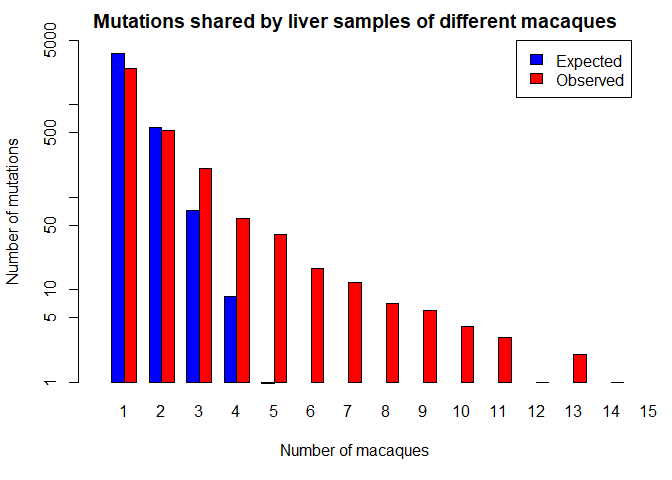

```r
shared_muscle_Rh_NA = shared_muscle_Rh[,c("exp_mut_tot","obs_mut_tot")]
shared_muscle_Rh_NA[shared_muscle_Rh_NA<0.5] = NA
barplot(t(shared_muscle_Rh_NA), xlab = "Number of macaques", ylab = "Number of mutations", main = "Mutations shared by liver samples of different macaques", log = "y", xlim = c(0,41), ylim = c(1,5000), beside = TRUE, col = c("blue", "red"))
legend("topright", legend = c("Expected", "Observed"), fill = c("blue", "red"))
```

### Hotspot mutations identification

In order to better identify the hotspot mutations, i.e. the mutations that are shared by multiple macaques but are not expected to be shared, we consider each of 882 shared mutations and we compute the probability of observing it exactly in those macaques in which we are observing it. This way, we can rank the shared mutations based on how unusual they are, taking into consideration in which macaques we found them (hence, also the sequencing depth for each sample).

For each of the 882 shared mutation, we consider the $n_{Rh,i}$ macaques in which we observed it. If the mutation is present in the macaques $j, \dots, j_{n_{Rh,i}}$ and is not present in the macaques $k, \dots, k_{n_{Rh}-n_{Rh,i}}$, assuming independence among random mutations in different macaques we obtain that the probability of observing such a mutation in exactly those macaques is $q_j \times \cdots \times q_{j_{n_{Rh,i}}} \times (1-q_k) \times \cdots \times (1-q_{k_{n_{Rh}-n_{Rh,i}}})$.

```r
mut_shared_muscle_prob = unique(mut_shared_muscle[,c("mutation", "gene_type", "n_Rh")])
mut_shared_muscle_prob$prob = unlist(lapply(unique(mut_shared_muscle$mutation),
                                           function(mutation){
                                             mut_shared_i = mut_shared_muscle[mut_shared_muscle$mutation==mutation,]
                                             if(mut_shared_i$gene_type[1]=="D-loop"){
                                               q = mut_muscle$q_D
                                             }else{
                                               q = mut_muscle$q_nonD
                                             }
                                             j = mut_muscle$macaque_ID %in% mut_shared_i$macaque_ID
                                             return(prod(c(q[j], (1-q[!j]))))
                                           }))
mut_shared_muscle_prob = mut_shared_muscle_prob[order(mut_shared_muscle_prob$prob),]
head(mut_shared_muscle_prob)
```

|  | mutation | gene_type | n_Rh | prob |
| --- | --- | --- | --- | --- |
| 2510 | 198 C>T | D-loop | 14 | 4.395029e-24 |
| 2086 | 16304 G>A | D-loop | 13 | 8.490373e-23 |
| 912 | 13279 G>A | protein coding | 10 | 5.191734e-22 |
| 4544 | 845 G>A | rRNA | 10 | 1.533555e-21 |
| 390 | 11553 G>A | protein coding | 10 | 5.942889e-21 |
| 879 | 13171 G>A | protein coding | 9 | 1.635639e-20 |

Save results:

```r
write_xlsx(mut_shared_muscle_prob, "shared_mutation_multiple_Rh_muscle.xlsx")
```